# Porous use case

## Intro

This poorly written vignette contains one working example of how to run the model in its current state.  
The code is organized in a series of functions.

[interactive chart not shown]

## Example: how to to run the model.

```r
library(Porous)
library(SoilR) #this should load automatically anyway since it is required by Porous
```

First we create the model object:

```r
 modelObject<-Porous()
```

This creates a model with the default parameters. The parameter values can also be specified by the user (when one value is not specified the parameter will have default value), such as:

```r
modelObject<-Porous(ky=0.8, ko=0.00605,
                    kmix=0.9,
                    e=0.13,
                    Im=1.1, Ir=0.5,
                    F_prot=0.0,
                    phi_mac=0.2,
                    phi_min=1,
                    clay=0.2,
                    Delta_z_min=20,
                    gamma_o=1.2)
```

Many values can be omitted, and the function will use the defaults. In particular `f_text_mic`, if omitted, will be calculated internally with a specific function, `f_text_mic_func()`.

`SoilR` has an internal function designed to plot any model (but fluxes do not always seem consistent in the representation):

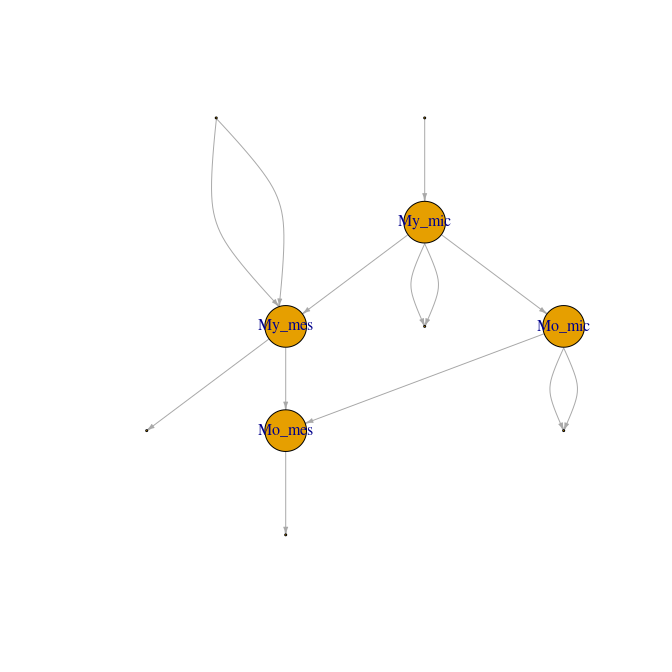

```r
plotPoolGraph(modelObject)
```

Now we can run the model, for wich we need to initialize the starting values

```r
init<-c(My_mes=1, Mo_mes=10,My_mic=0.6, Mo_mic=3)
times<-seq(0,20,by=0.1)
```

We can then run the model with the specific `SoilR` function:

```r
modrun0<-Model_by_PoolNames(smod=modelObject, times=times, initialValues=init)
```

And, again relying on the specific `SoilR` function, we can extract the C stocks and respiration fluxes:

```r
Stocks<-getC(modrun0)
Resp<-getReleaseFlux(modrun0)
```

Let’s see what object we created (by plotting just the first rows of it):

```r
head(Resp)
```

```
#>           [,1] [,2]         [,3]      [,4]
#> [1,] 0.8000000    0 -0.360000000 -6.300000
#> [2,] 0.7257902    0 -0.200615068 -4.817084
#> [3,] 0.6696608    0 -0.087480390 -3.684389
#> [4,] 0.6266788    0 -0.007528916 -2.819208
#> [5,] 0.5932938    0  0.048621137 -2.158377
#> [6,] 0.5669394    0  0.087728304 -1.653596
```

Everything seems in order and we can proceed to plot:

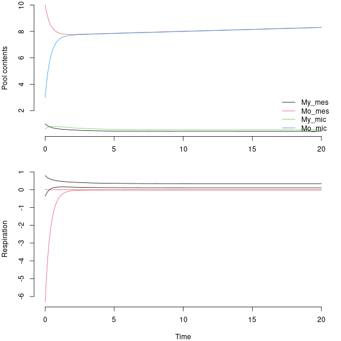

```r
par(mfrow=c(2,1), mar=c(4,4,0,1))
matplot(times, Stocks, type="l", lty=1, col=1:4, xlab=" ", ylab="Pool contents", bty="n")
legend("bottomright", c("My_mes", "Mo_mes", "My_mic", "Mo_mic"), lty=1, col=1:4, bty="n")
matplot(times, Resp,  type="l", lty=1, col=1:2, xlab="Time", ylab="Respiration", bty="n")
```

```r
f_som(My_mic=Stocks[,1],
      Mo_mic=Stocks[,2],
      My_mes=Stocks[,3],
      Mo_mes=Stocks[,4],
      Delta_z_min=20,
      phi_min=0.35,
      gamma_m=1.1)
```

```
#>   [1] 0.5051903 0.5144970 0.5212742 0.5262390 0.5298873 0.5325699 0.5345388
#>   [8] 0.5359782 0.5370233 0.5377745 0.5383069 0.5386765 0.5389256 0.5390857
#>  [15] 0.5391810 0.5392292 0.5392441 0.5392357 0.5392117 0.5391777 0.5391382
#>  [22] 0.5390961 0.5390538 0.5390129 0.5389747 0.5389399 0.5389091 0.5388827
#>  [29] 0.5388608 0.5388436 0.5388311 0.5388231 0.5388197 0.5388207 0.5388259
#>  [36] 0.5388352 0.5388485 0.5388655 0.5388861 0.5389102 0.5389375 0.5389679
#>  [43] 0.5390013 0.5390375 0.5390764 0.5391178 0.5391617 0.5392078 0.5392561
#>  [50] 0.5393064 0.5393587 0.5394129 0.5394688 0.5395263 0.5395854 0.5396461
#>  [57] 0.5397081 0.5397715 0.5398361 0.5399019 0.5399689 0.5400369 0.5401060
#>  [64] 0.5401760 0.5402469 0.5403187 0.5403913 0.5404647 0.5405388 0.5406136
#>  [71] 0.5406891 0.5407652 0.5408418 0.5409190 0.5409968 0.5410750 0.5411537
#>  [78] 0.5412328 0.5413124 0.5413923 0.5414726 0.5415533 0.5416342 0.5417155
#>  [85] 0.5417971 0.5418790 0.5419611 0.5420435 0.5421261 0.5422089 0.5422919
#>  [92] 0.5423751 0.5424585 0.5425420 0.5426258 0.5427096 0.5427936 0.5428777
#>  [99] 0.5429620 0.5430464 0.5431308 0.5432154 0.5433000 0.5433848 0.5434696
#> [106] 0.5435545 0.5436395 0.5437245 0.5438096 0.5438947 0.5439799 0.5440651
#> [113] 0.5441504 0.5442357 0.5443210 0.5444064 0.5444918 0.5445772 0.5446626
#> [120] 0.5447480 0.5448335 0.5449190 0.5450045 0.5450900 0.5451755 0.5452610
#> [127] 0.5453465 0.5454320 0.5455175 0.5456030 0.5456885 0.5457739 0.5458594
#> [134] 0.5459449 0.5460303 0.5461158 0.5462012 0.5462866 0.5463720 0.5464574
#> [141] 0.5465428 0.5466282 0.5467135 0.5467988 0.5468841 0.5469694 0.5470547
#> [148] 0.5471399 0.5472251 0.5473103 0.5473955 0.5474806 0.5475657 0.5476508
#> [155] 0.5477359 0.5478209 0.5479060 0.5479910 0.5480759 0.5481609 0.5482458
#> [162] 0.5483307 0.5484155 0.5485004 0.5485852 0.5486699 0.5487547 0.5488394
#> [169] 0.5489241 0.5490088 0.5490934 0.5491780 0.5492626 0.5493471 0.5494316
#> [176] 0.5495161 0.5496006 0.5496850 0.5497694 0.5498537 0.5499381 0.5500224
#> [183] 0.5501066 0.5501909 0.5502751 0.5503593 0.5504434 0.5505275 0.5506116
#> [190] 0.5506957 0.5507797 0.5508637 0.5509477 0.5510316 0.5511155 0.5511994
#> [197] 0.5512832 0.5513670 0.5514508 0.5515345 0.5516183
```

```r
gamma_b(My_mic=Stocks[,1],
        Mo_mic=Stocks[,2],
        My_mes=Stocks[,3],
        Mo_mes=Stocks[,4],
        Delta_z_min=20,
        phi_min=1,
        gamma_o=1.2,
        gamma_m=1.1,
        f_agg=3,
        phi_mac=0.2)
```

```
#>   [1] 0.1700971 0.1719277 0.1732436 0.1741985 0.1748954 0.1754052 0.1757780
#>   [8] 0.1760498 0.1762467 0.1763881 0.1764882 0.1765576 0.1766044 0.1766345
#>  [15] 0.1766524 0.1766614 0.1766642 0.1766626 0.1766581 0.1766517 0.1766443
#>  [22] 0.1766364 0.1766285 0.1766208 0.1766136 0.1766071 0.1766013 0.1765964
#>  [29] 0.1765923 0.1765890 0.1765867 0.1765852 0.1765845 0.1765847 0.1765857
#>  [36] 0.1765875 0.1765899 0.1765931 0.1765970 0.1766015 0.1766067 0.1766124
#>  [43] 0.1766186 0.1766254 0.1766327 0.1766405 0.1766487 0.1766574 0.1766664
#>  [50] 0.1766759 0.1766857 0.1766959 0.1767063 0.1767171 0.1767282 0.1767396
#>  [57] 0.1767512 0.1767631 0.1767752 0.1767876 0.1768001 0.1768129 0.1768258
#>  [64] 0.1768389 0.1768522 0.1768657 0.1768793 0.1768930 0.1769069 0.1769209
#>  [71] 0.1769350 0.1769493 0.1769636 0.1769781 0.1769926 0.1770073 0.1770220
#>  [78] 0.1770368 0.1770517 0.1770666 0.1770816 0.1770967 0.1771118 0.1771270
#>  [85] 0.1771423 0.1771576 0.1771729 0.1771883 0.1772037 0.1772192 0.1772347
#>  [92] 0.1772503 0.1772658 0.1772814 0.1772970 0.1773127 0.1773284 0.1773441
#>  [99] 0.1773598 0.1773755 0.1773913 0.1774070 0.1774228 0.1774386 0.1774544
#> [106] 0.1774703 0.1774861 0.1775019 0.1775178 0.1775336 0.1775495 0.1775654
#> [113] 0.1775813 0.1775971 0.1776130 0.1776289 0.1776448 0.1776607 0.1776766
#> [120] 0.1776925 0.1777084 0.1777243 0.1777402 0.1777561 0.1777720 0.1777879
#> [127] 0.1778037 0.1778196 0.1778355 0.1778514 0.1778673 0.1778832 0.1778990
#> [134] 0.1779149 0.1779308 0.1779466 0.1779625 0.1779783 0.1779942 0.1780100
#> [141] 0.1780259 0.1780417 0.1780575 0.1780733 0.1780892 0.1781050 0.1781208
#> [148] 0.1781366 0.1781524 0.1781681 0.1781839 0.1781997 0.1782155 0.1782312
#> [155] 0.1782470 0.1782627 0.1782785 0.1782942 0.1783099 0.1783256 0.1783413
#> [162] 0.1783570 0.1783727 0.1783884 0.1784041 0.1784198 0.1784354 0.1784511
#> [169] 0.1784667 0.1784824 0.1784980 0.1785137 0.1785293 0.1785449 0.1785605
#> [176] 0.1785761 0.1785917 0.1786073 0.1786228 0.1786384 0.1786540 0.1786695
#> [183] 0.1786851 0.1787006 0.1787161 0.1787317 0.1787472 0.1787627 0.1787782
#> [190] 0.1787937 0.1788092 0.1788246 0.1788401 0.1788556 0.1788710 0.1788865
#> [197] 0.1789019 0.1789173 0.1789327 0.1789482 0.1789636
```

All the above functions can be run with a wrapper, `run_Porous`, that takes care of running the simulation and calculating bulk density and C concentration:

```r
results<-run_Porous(ky=0.8, ko=0.035,
                     kmix=0.05,
                     e=0.143,
                     Im=1.1, Ir=0.5,
                     F_prot=0.1,
                     phi_mac=0.152,
                     clay=0.2,
                     Delta_z_min=4,
                     gamma_o=1.2,
                     gamma_m=1.3,
                     proportion=NULL,
                     phi_min=0.35,
                     f_text_mic=NULL,
                     f_agg=3,
                     init=c(My_mes=1, Mo_mes=10,My_mic=0.6, Mo_mic=3),
                     sim_length=20,
                     sim_steps=0.1)

head(results)
```

```
#>   time My_mes.stocks Mo_mes.stocks My_mic.stocks Mo_mic.stocks My_mes.resp
#> 1  0.0     1.0000000     10.000000     0.6000000      3.000000   0.8000000
#> 2  0.1     0.9232926      9.976229     0.6398303      3.070239   0.7386341
#> 3  0.2     0.8541572      9.952093     0.6781480      3.139585   0.6833257
#> 4  0.3     0.7918762      9.927672     0.7150541      3.208042   0.6335009
#> 5  0.4     0.7358023      9.903037     0.7506410      3.275615   0.5886419
#> 6  0.5     0.6853481      9.878253     0.7849931      3.342310   0.5482785
#>   Mo_mes.resp   My_mic.resp Mo_mic.resp f_som_sim gamma_b_sim
#> 1           0 -0.0200000000  -0.3500000 0.8120133   0.2895008
#> 2           0 -0.0141731163  -0.3452995 0.8121136   0.2894795
#> 3           0 -0.0088004601  -0.3406254 0.8122638   0.2894476
#> 4           0 -0.0038411011  -0.3359815 0.8124582   0.2894063
#> 5           0  0.0007419313  -0.3313711 0.8126915   0.2893567
#> 6           0  0.0049822496  -0.3267972 0.8129590   0.2893000
```

We can also specify a user-defined `f_text_mic`:

```r
results<-run_Porous(ky=0.8, ko=0.035,
                    kmix=0.05,
                    e=0.143,
                    Im=1.1, Ir=0.5,
                    F_prot=0.1,
                    phi_mac=0.152,
                    clay=0.2,
                    Delta_z_min=4,
                    gamma_o=1.2,
                    gamma_m=1.3,
                    proportion=NULL,
                    phi_min=0.35,
                    f_text_mic=0.507,
                    f_agg=3,
                    init=c(My_mes=1, Mo_mes=10,My_mic=0.6, Mo_mic=3),
                    sim_length=100,
                    sim_steps=0.1)
```

Results can be accessed as plotted as a data frame:

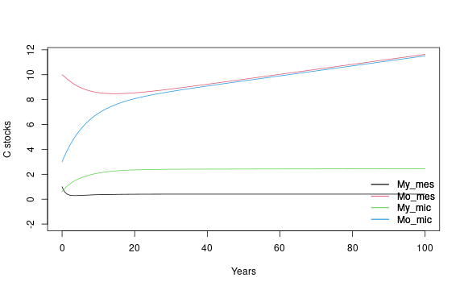

```r
range_stocks<-range(results[,2:5])
plot(results$time, results$My_mes.stocks, ylim=c(-2,range_stocks[2]), type="l", col=1, xlab="Years", ylab="C stocks")
lines(results$time, results$Mo_mes.stocks, ylim=range_stocks, type="l", col=2)
lines(results$time, results$My_mic.stocks, ylim=range_stocks, type="l", col=3)
lines(results$time, results$Mo_mic.stocks, ylim=range_stocks, type="l", col=4)
legend("bottomright", c("My_mes", "Mo_mes", "My_mic", "Mo_mic"), lty=1, col=1:4, bty="n")
legend("bottomright", c("My_mes", "Mo_mes", "My_mic", "Mo_mic"), lty=1, col=1:4, bty="n")
```